# DO-MS Report

Version: 1.0.9 | Generated: 2020-08-31 14:24:48

## Summary

### MaxQuant Search Summary

MaxQuant Search Summary

MaxQuant Version: 1.6.7.0, 11

Search Date: 03/09/2020 19:20:09, 9

FASTA File: /home/huffman.r/FASTA/SwissProt_human_09042017.fasta, 1

### Experiment Map

Map of raw file names to short names

| Short name | Raw file | Folder | Path |
| --- | --- | --- | --- |
| 100-cell | hs0041 | hs0041 | G:/My Drive/MS/cluster_searches/hs0041 |
| 200-cell | hs0042 | hs0042 | G:/My Drive/MS/cluster_searches/hs0042 |
| 300-cell | hs0043 | hs0043 | G:/My Drive/MS/cluster_searches/hs0043 |
| 400-cell | hs0044 | hs0044 | G:/My Drive/MS/cluster_searches/hs0044 |
| 600-cell | hs0045 | hs0045 | G:/My Drive/MS/cluster_searches/hs0045 |
| 800-cell | hs0046 | hs0046 | G:/My Drive/MS/cluster_searches/hs0046 |

### MaxQuant Parameters

MaxQuant Search Parameters

|  | Parameter | hs0041 | hs0042 | hs0043 | hs0044 | hs0045 | hs0046 |
| --- | --- | --- | --- | --- | --- | --- | --- |
| 1 | Folder Name | hs0041 | hs0042 | hs0043 | hs0044 | hs0045 | hs0046 |
| 2 | Folder Path | G:/My Drive/MS/cluster_searches/hs0041 | G:/My Drive/MS/cluster_searches/hs0042 | G:/My Drive/MS/cluster_searches/hs0043 | G:/My Drive/MS/cluster_searches/hs0044 | G:/My Drive/MS/cluster_searches/hs0045 | G:/My Drive/MS/cluster_searches/hs0046 |
| 3 | Version | 1.6.7.0 | 1.6.7.0 | 1.6.7.0 | 1.6.7.0 | 1.6.7.0 | 1.6.7.0 |
| 4 | User name | huffman.r | huffman.r | huffman.r | huffman.r | huffman.r | huffman.r |
| 5 | Machine name | c0195 | c0171 | c0196 | c0193 | c0201 | c0171 |
| 6 | Date of writing | 03/09/2020 19:20:09 | 03/07/2020 16:23:49 | 03/07/2020 17:20:12 | 03/07/2020 19:01:43 | 03/07/2020 20:38:21 | 03/07/2020 22:24:41 |
| 7 | Include contaminants | True | True | True | True | True | True |
| 8 | PSM FDR | 1 | 1 | 1 | 1 | 1 | 1 |
| 9 | PSM FDR Crosslink | 0.01 | 0.01 | 0.01 | 0.01 | 0.01 | 0.01 |
| 10 | Protein FDR | 1 | 1 | 1 | 1 | 1 | 1 |

[output cut: 96 more lines]

### MaxQuant Experiment Summary

MaxQuant experiment summary statistics

|  | Raw.file | Raw.file.orig | Enzyme | Enzyme.mode | Enzyme.first.search | Enzyme.mode.first.search | Use.enzyme.first.search | Variable.modifications | Fixed.modifications | Multi.modifications | Variable.modifications.first.search | Use.variable.modifications.first.search | Requantify | Multiplicity | Max..missed.cleavages | Labels0 | LC.MS.run.type | Time.dependent.recalibration | MS | MS.MS | MS3 | MS.MS.Submitted | MS.MS.Submitted..SIL. | MS.MS.Submitted..ISO. | MS.MS.Submitted..PEAK. | MS.MS.Identified | MS.MS.Identified..SIL. | MS.MS.Identified..ISO. | MS.MS.Identified..PEAK. | … |
| --- | --- | --- | --- | --- | --- | --- | --- | --- | --- | --- | --- | --- | --- | --- | --- | --- | --- | --- | --- | --- | --- | --- | --- | --- | --- | --- | --- | --- | --- | --- |
| 1 | 100-cell | hs0041 | Trypsin/P | Specific |  |  | False | Oxidation (M);Acetyl (Protein N-term) |  |  |  | False | False | 1 | 2 |  | Reporter ion MS2 |  | 7821 | 7354 | 0 | 8199 | 6509 | 0 | 1690 | 4893 | 4388 | 0 | 505 | … |
| 2 | 200-cell | hs0042 | Trypsin/P | Specific |  |  | False | Oxidation (M);Acetyl (Protein N-term) |  |  |  | False | False | 1 | 2 |  | Reporter ion MS2 |  | 6738 | 8812 | 0 | 9856 | 7768 | 0 | 2088 | 6098 | 5436 | 0 | 662 | … |
| 3 | 300-cell | hs0043 | Trypsin/P | Specific |  |  | False | Oxidation (M);Acetyl (Protein N-term) |  |  |  | False | False | 1 | 2 |  | Reporter ion MS2 |  | 7247 | 7974 | 0 | 8920 | 7028 | 0 | 1892 | 5457 | 4870 | 0 | 587 | … |
| 4 | 400-cell | hs0044 | Trypsin/P | Specific |  |  | False | Oxidation (M);Acetyl (Protein N-term) |  |  |  | False | False | 1 | 2 |  | Reporter ion MS2 |  | 6443 | 9543 | 0 | 10589 | 8497 | 0 | 2092 | 6684 | 6020 | 0 | 664 | … |
| 5 | 600-cell | hs0045 | Trypsin/P | Specific |  |  | False | Oxidation (M);Acetyl (Protein N-term) |  |  |  | False | False | 1 | 2 |  | Reporter ion MS2 |  | 6289 | 9846 | 0 | 10901 | 8791 | 0 | 2110 | 6945 | 6279 | 0 | 666 | … |
| 6 | 800-cell | hs0046 | Trypsin/P | Specific |  |  | False | Oxidation (M);Acetyl (Protein N-term) |  |  |  | False | False | 1 | 2 |  | Reporter ion MS2 |  | 6096 | 10199 | 0 | 11303 | 9095 | 0 | 2208 | 7291 | 6566 | 0 | 725 | … |

## Chromatography

### Elution profile: FWHM

Plotting the distrution of elution profile widths at half the maximum intensity value for each peak.

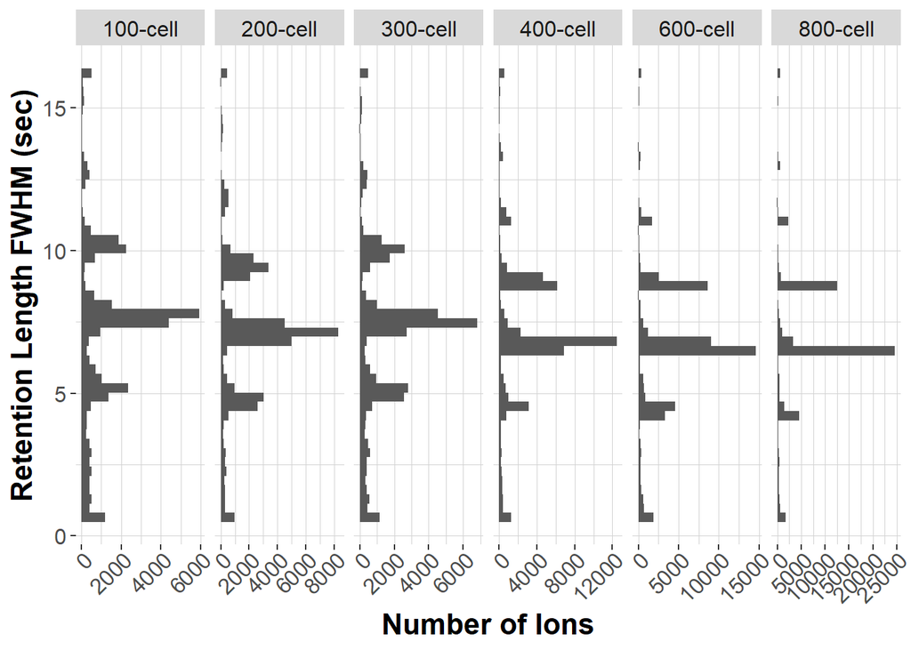

### Identification frequency across gradient

Plotting the frequency of peptide identification across the chromatographic gradient.

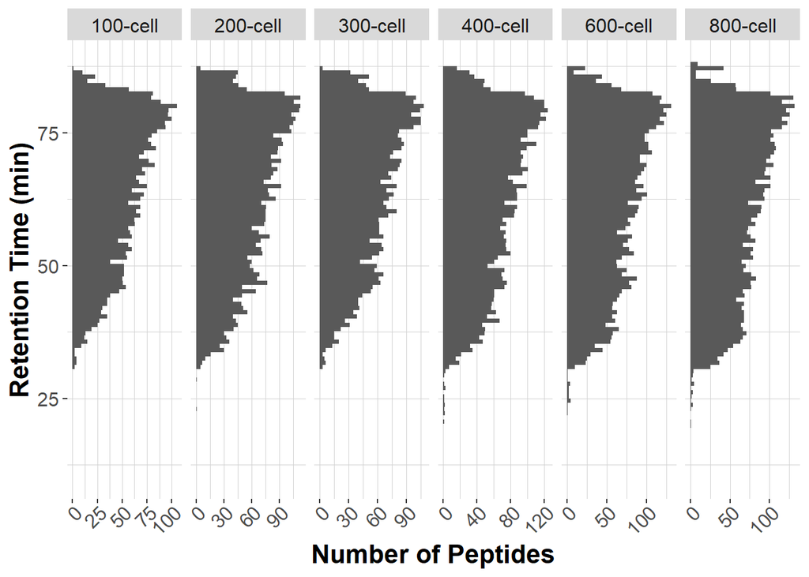

### Retention length of peptides at base

Plotting the retention length of identified peptide peaks at the base.

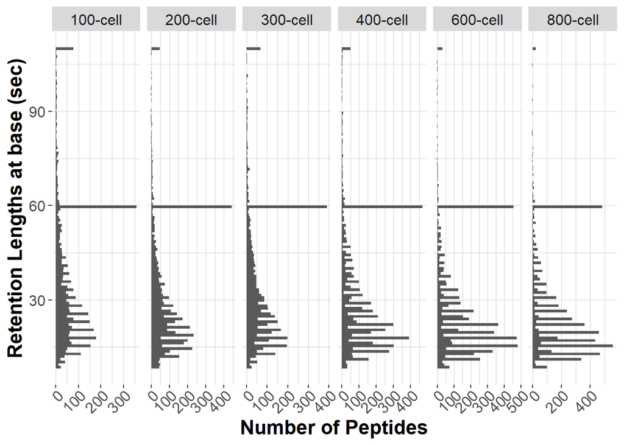

## Ion Sampling

### Apex Offset

Plotting the distance from the peak of the elution profile the MS2 events were executed.

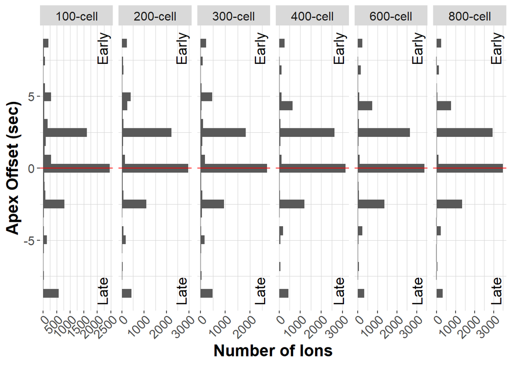

### MS1 Intensity for identified ions

Plotting the MS1 intensity for all identified ions across runs.

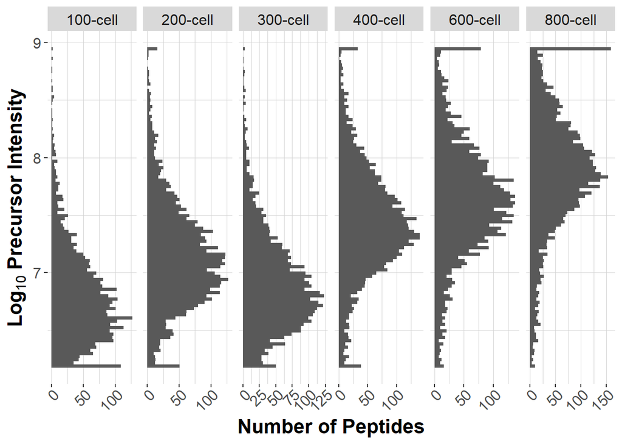

### MS1 Intensity for z>1 ions

Plotting the MS1 intensity for all peptide-like ions observed (not necessarily sent to MS2) across runs.

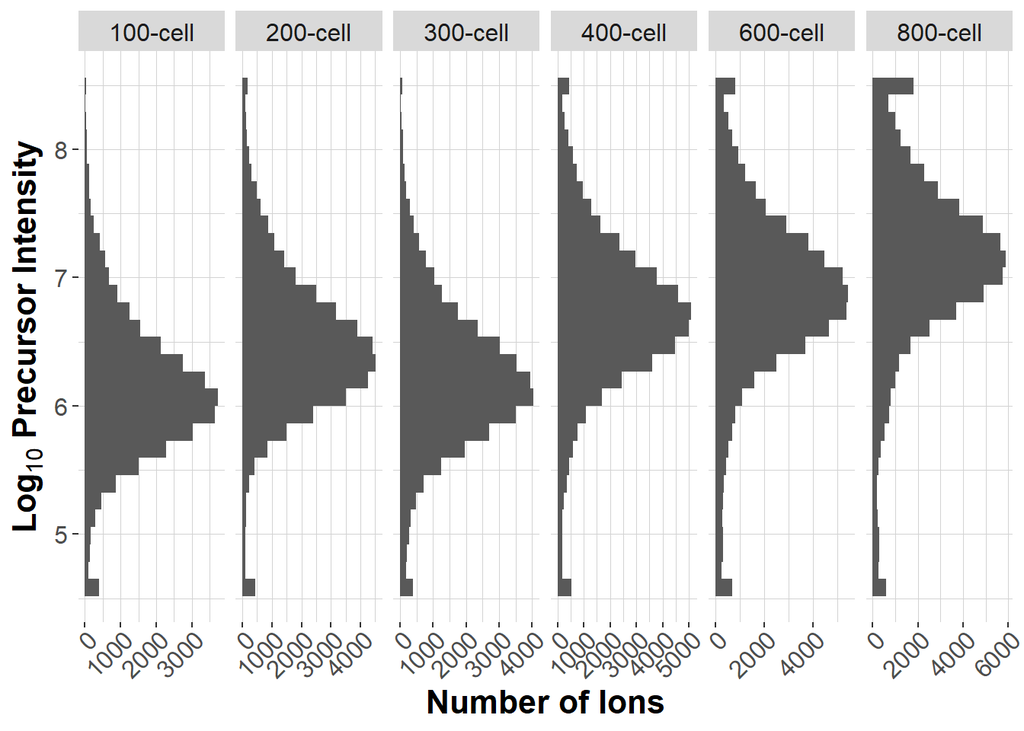

### MS1 Intensity for identified ions in common

Plotting the MS1 intensity for all common identified ions across runs.

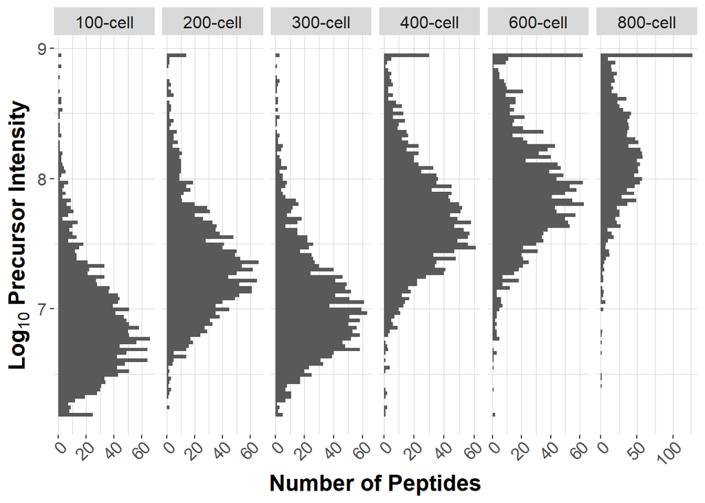

### MS1 Intensity for all ions

Plotting the MS1 intensity for all ions observed (not necessarily sent to MS2) across runs.

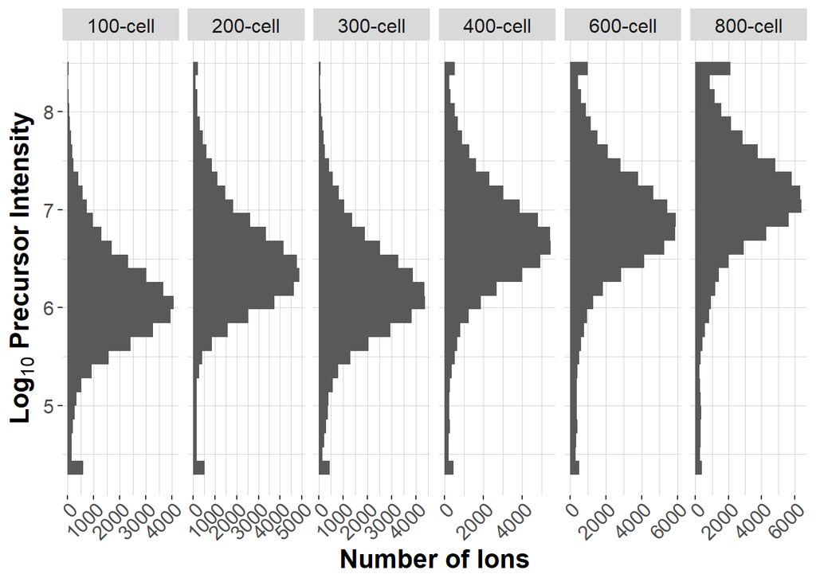

### Injection times, PSM resulting

Plotting distribution of injection times for MS2 events that did result in a PSM.

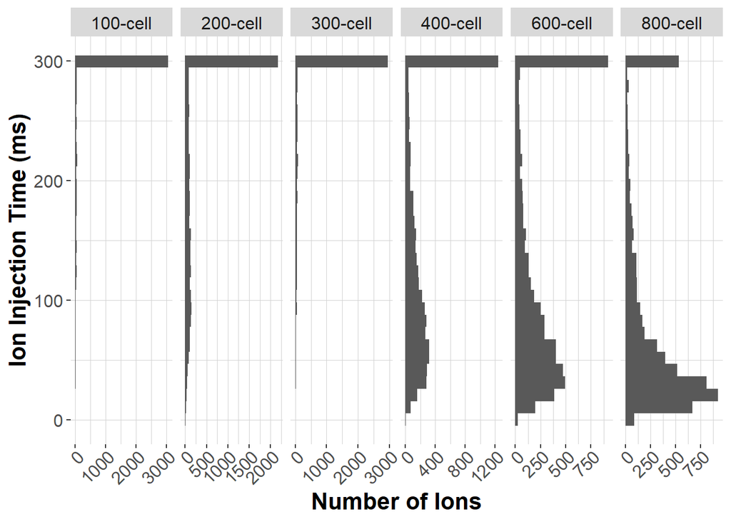

### Injection times, no PSM resulting

Plotting distribution of injection times for MS2 events that did not result in a PSM.

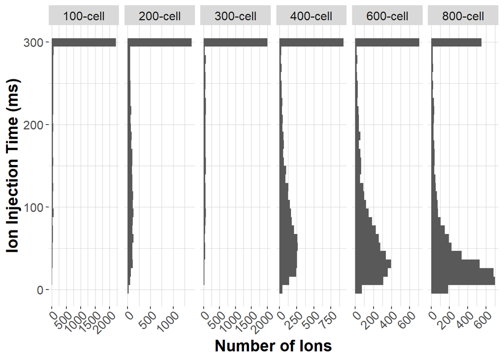

## Peptide Identifications

### Miscleavage rate

Plotting frequency of peptide miscleavages.

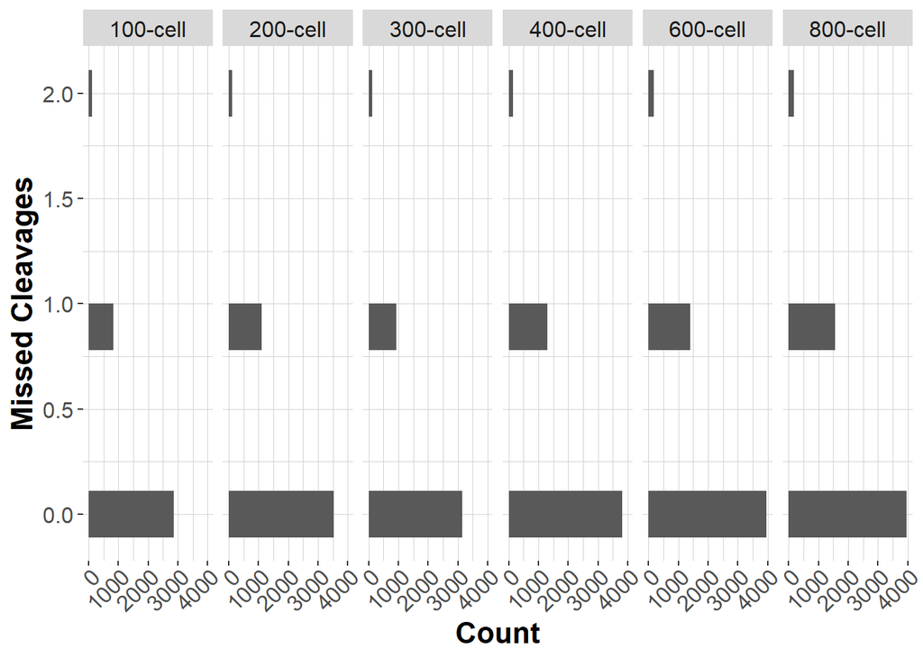

### Miscleavage rate percentage

Percentages of missed cleavages - measure the efficiency of protein digest

| Raw.file | None | 1 | 2 | % Missed cleavages |
| --- | --- | --- | --- | --- |
| 100-cell | 2858 | 820 | 105 | 26.49177 |
| 200-cell | 3533 | 1103 | 127 | 27.75051 |
| 300-cell | 3151 | 936 | 119 | 27.14451 |
| 400-cell | 3817 | 1293 | 146 | 29.34098 |
| 600-cell | 3960 | 1396 | 173 | 30.55068 |
| 800-cell | 3971 | 1553 | 189 | 32.71772 |

### Number of Confident Identifications

Plotting the number of peptides identified at each given confidence level.

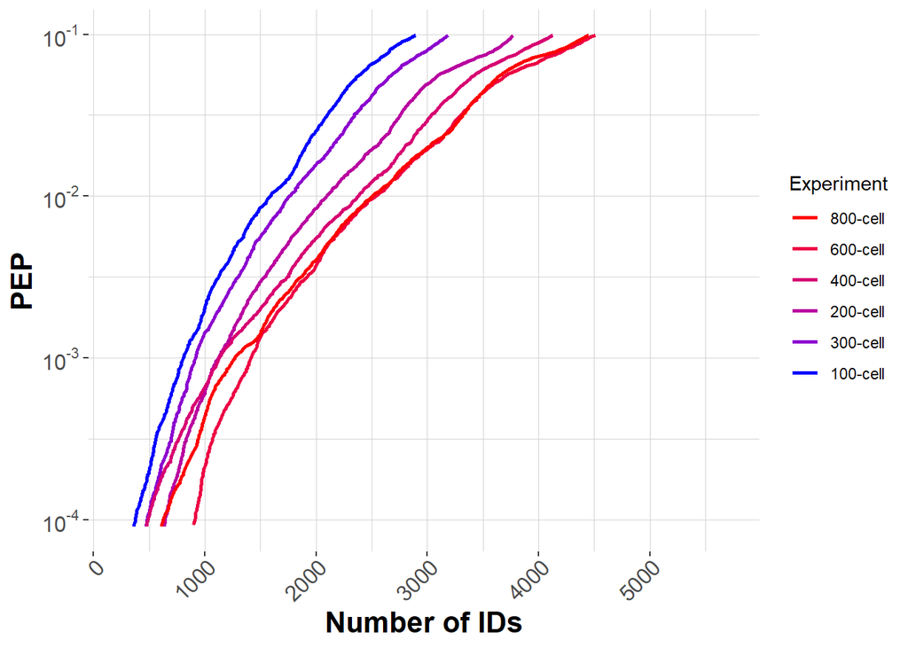

### Precursor Ion Fraction (PIF)

The distribution of PIFs for identified peptides across all sets, where PIF is a measure of coisolation (1 = pure, 0 = impure).

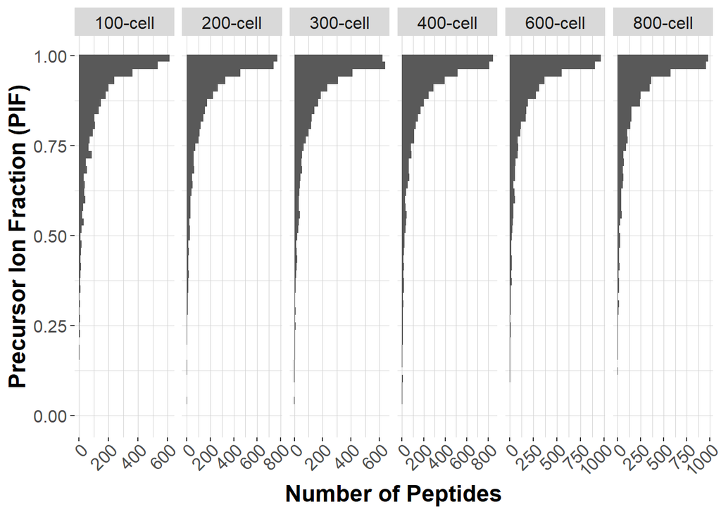

### Fractional ID Rate

Fractional rate of confident PSMs and PSMs from all MS2 scan events

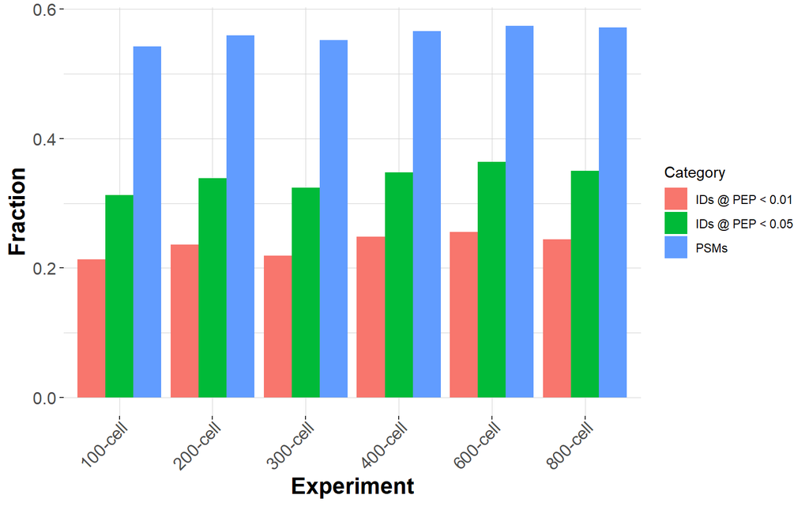

### Total ID Rate

Number of MSMS scans, PSMs, and confident PSMs

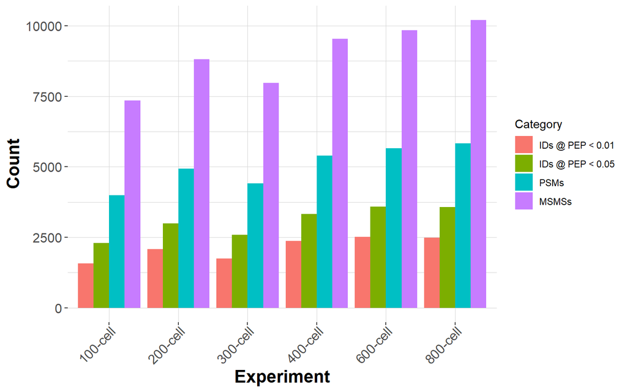

## Contamination

### Number of ions by charge state

Plotting the frequency of charge states observed. This will give an if you are seeing mostly peptides or non-peptide species

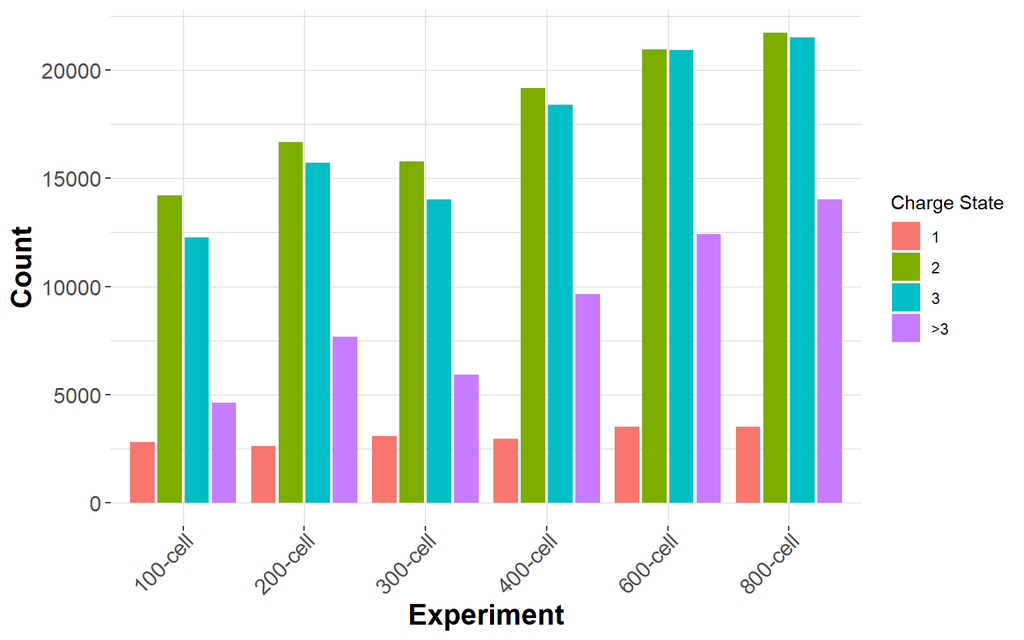

### TIC of ions by charge state

Plotting the TIC of charge states observed. This will give an idea if you are seeing mostly peptides or non-peptide species

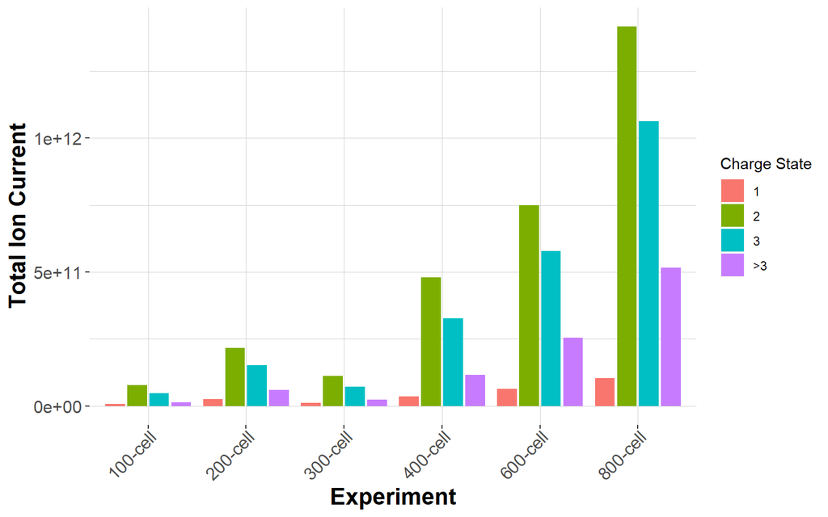

### MS1 Intensity, +1 ions

Plotting the intensity distribution of +1 ions, a diagnostic of non-peptide contaminants

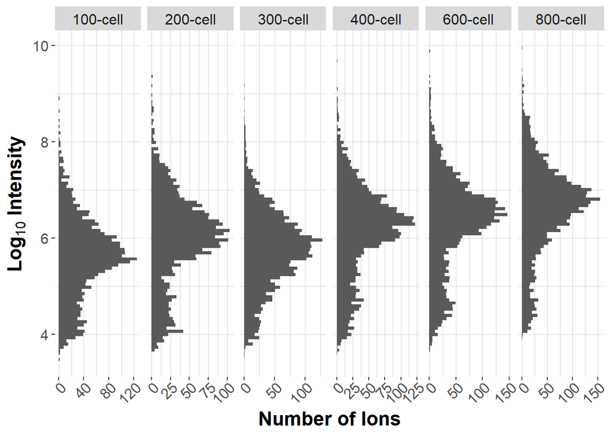

### m/z Distribution for +1 ions

Plotting the m/z distribution of +1 ions, a diagnostic of non-peptide contaminants

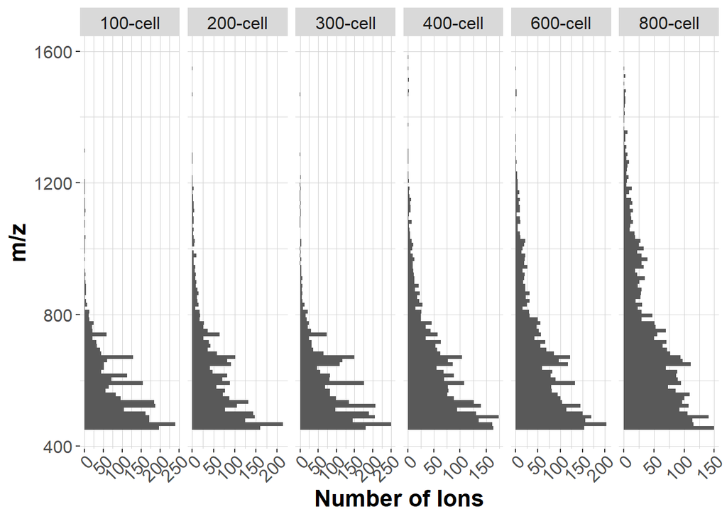

### Intensity of z=1 across gradient

Plotting the intensity of z=1 ions observed. This will give an if you are seeing mostly peptides or non-peptide species and where they occur in the gradient

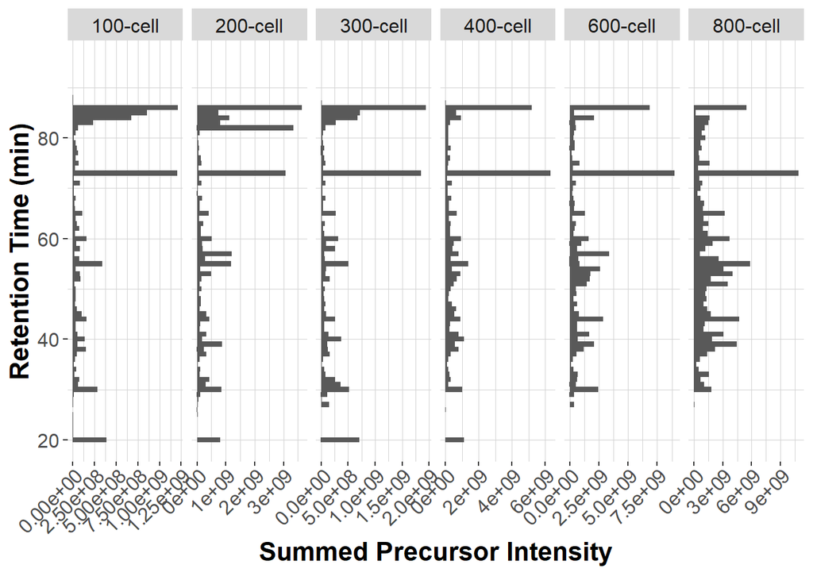

## SCoPE-MS Diagnostics

### Fraction of Missing Data per TMT Channel

This plot displays the fraction of missing values per reporter ion per run per TMT channel, reported as 0 by MaxQuant.

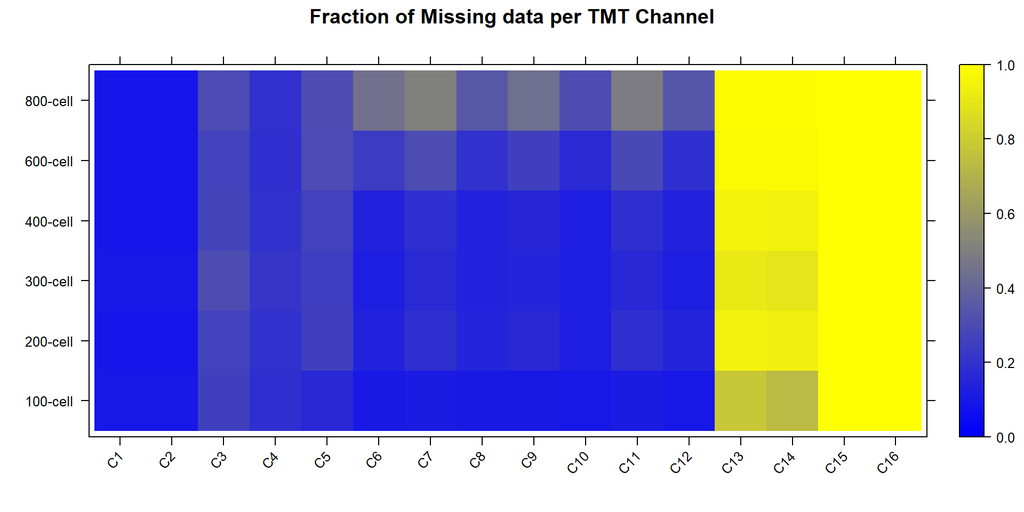

### Reporter Ion Intensities vs. Carrier Intensities

[output not shown]

### Reporter ion intensity

[output not shown]

### Relative reporter ion intensity

[output not shown]

### Reporter ion channel correlations

[output not shown]

## DART-ID

### Error Probability Update

[output not shown]

### Increase in Confident PSMs

[output not shown]

### RT Alignment Error

[output not shown]

### Peptide Identification Increase by Experiment

[output not shown]

### Fractional ID Rate

[output not shown]

### Total ID Rate

[output not shown]